# Assignment 9 RNAseq Differential Gene Expression

**Name:** Ricardo Pineda **Student ID:** 917486212

**Always include the code or commands used to answer the exercises**

**When done, knit an html and push both this .Rmd and the .html to your github.**

```r
library(tidyverse)
```

**Exercise 0:** Paste your code from the Stringr/RegEx tutorial here. Don’t worry about commenting them, just put them in the code chunk.

```r
#detect strings --------------------
bnames10 %>% str_detect("A")
#subset strings --------------------
bnames_th <- bnames10 %>% str_subset("th")
bnames_th
#Regex pt1 --------------------
bnames1000_i.i <- bnames1000 %>%
str_subset("i..i") %>%
str_view("i..i")
bnames1000_i.i
#---
bnamesearly %>% str_subset("e{1,2}z")
#Regex pt2 --------------------
bnames100 %>% str_subset("[AEIOU].")
#---
letters %>% str_subset("[^aeiou]")
#---
fruit %>% str_subset("berry|pepper")
#---
fruit %>% str_subset(" (berry|pepper)")
#---
fruit %>% str_subset("[^ ](berry|pepper)")
#Regex pt3 --------------------
fruit %>% str_subset("^[aeiou]")
#---
fruit %>% str_subset("^[aeiou].{0,}[aeiou]$")
#---
fruit %>% str_subset("^[aeiou]|[aeiou]$")
#More str fxns --------------------
bnames10 %>% str_remove("[aeiou]")
#---
bnames10 %>% str_remove_all("[aeiou]")
#---
knames %>% str_replace("K","C")
#Back references --------------------
bnames100 %>% tolower() %>% str_subset("^(.).{0,}\\1$")
#Mutate --------------------
people %>%
  mutate(last_name=str_remove(full_name,",.{0,}"))
#---
people %>%
  mutate(last_name=str_replace(full_name, "(.*), .*", "\\1"))
#---
people %>%
  mutate(first_last=str_replace(full_name, "(.*), (.*)", "\\2 \\1"))
```

**Exercise 1**  
Read the help file for `featureCounts()`. Be sure to look at the section “Value” where it describes the output.

```r
library(Rsubread)
readCounts <- featureCounts(
  files=c("../../assignment08-rhpineda/output/tophat_out-IMB211_A03_INTERNODE/accepted_hits_A03.bam",
    "../../assignment08-rhpineda/output/tophat_out-R500_A03_INTERNODE/accepted_hits_A03.bam"),
  annot.ext="../../assignment08-rhpineda/input/Brapa_reference/Brapa_gene_v1.5.gff",
  isGTFAnnotationFile=TRUE,
  GTF.featureType="CDS", # This depends on GFF file.  Often it would be "exon"
  GTF.attrType="Parent"
  )
```

```
##
##         ==========     _____ _    _ ____  _____  ______          _____
##         =====         / ____| |  | |  _ \|  __ \|  ____|   /\   |  __ \
##           =====      | (___ | |  | | |_) | |__) | |__     /  \  | |  | |
##             ====      \___ \| |  | |  _ <|  _  /|  __|   / /\ \ | |  | |
##               ====    ____) | |__| | |_) | | \ \| |____ / ____ \| |__| |
##         ==========   |_____/ \____/|____/|_|  \_\______/_/    \_\_____/
##        Rsubread 2.12.3
##
## //========================== featureCounts setting ===========================\\
## ||                                                                            ||
## ||             Input files : 2 BAM files                                      ||
## ||                                                                            ||
## ||                           accepted_hits_A03.bam                            ||
## ||                           accepted_hits_A03.bam                            ||
## ||                                                                            ||
## ||              Paired-end : no                                               ||
## ||        Count read pairs : no                                               ||
## ||              Annotation : Brapa_gene_v1.5.gff (GTF)                        ||
## ||      Dir for temp files : .                                                ||
## ||                 Threads : 1                                                ||
## ||                   Level : meta-feature level                               ||
## ||      Multimapping reads : counted                                          ||
## || Multi-overlapping reads : not counted                                      ||
## ||   Min overlapping bases : 1                                                ||
## ||                                                                            ||
## \\============================================================================//
##
## //================================= Running ==================================\\
## ||                                                                            ||
## || Load annotation file Brapa_gene_v1.5.gff ...                               ||
## ||    Features : 206584                                                       ||
## ||    Meta-features : 41020                                                   ||
## ||    Chromosomes/contigs : 284                                               ||
## ||                                                                            ||
## || Process BAM file accepted_hits_A03.bam...                                  ||
## ||    Single-end reads are included.                                          ||
## ||    Total alignments : 3165935                                              ||
## ||    Successfully assigned alignments : 2718068 (85.9%)                      ||
## ||    Running time : 0.07 minutes                                             ||
## ||                                                                            ||
## || Process BAM file accepted_hits_A03.bam...                                  ||
## ||    Single-end reads are included.                                          ||
## ||    Total alignments : 3490437                                              ||
## ||    Successfully assigned alignments : 2977742 (85.3%)                      ||
## ||    Running time : 0.07 minutes                                             ||
## ||                                                                            ||
## || Write the final count table.                                               ||
## || Write the read assignment summary.                                         ||
## ||                                                                            ||
## \\============================================================================//
```

```r
#--------
#Below is used for testing what `counts.data` from 2b is analagous to
#testreadCounts <- featureCounts(
#  files=("../../assignment08-rhpineda/output/tophat_out-IMB211_A03_INTERNODE/accepted_hits_A03.bam"),
#  annot.ext="../../assignment08-rhpineda/input/Brapa_reference/Brapa_gene_v1.5.gff",
#  isGTFAnnotationFile=TRUE,
#  GTF.featureType="CDS", # This depends on GFF file.  Often it would be "exon"
#  GTF.attrType="Parent"
#  )

#testreadCounts$counts
```

**a** Provide a line of code that displays the counts of the first 6 genes.

```r
head(readCounts$counts, 6)
```

```
##           ../../assignment08-rhpineda/output/tophat_out-IMB211_A03_INTERNODE/accepted_hits_A03.bam
## Bra000001                                                                                        3
## Bra000002                                                                                      160
## Bra000003                                                                                      323
## Bra000004                                                                                       12
## Bra000005                                                                                     1364
## Bra000006                                                                                      460
##           ../../assignment08-rhpineda/output/tophat_out-R500_A03_INTERNODE/accepted_hits_A03.bam
## Bra000001                                                                                      2
## Bra000002                                                                                     18
## Bra000003                                                                                    356
## Bra000004                                                                                      1
## Bra000005                                                                                   2360
## Bra000006                                                                                    624
```

**b** The gene `Bra017676` is on chromosome A03. What are its read counts in the two files? (Show code)

Read counts:  
- IMB211 : 68  
- R500 : 128

```r
readCounts$counts['Bra017676',]
```

```
## ../../assignment08-rhpineda/output/tophat_out-IMB211_A03_INTERNODE/accepted_hits_A03.bam
##                                                                                       68
##   ../../assignment08-rhpineda/output/tophat_out-R500_A03_INTERNODE/accepted_hits_A03.bam
##                                                                                      128
```

**c** What percentage of reads (from each file) were assigned to a gene? What percentage were unassigned because they were not located in a gene (aka “Feature”)?

```r
percentstat <- readCounts[['stat']]
names(percentstat)[c(2,3)] <- c("IMB211", "R500")
totreadstat <- colSums(percentstat[, c('IMB211', 'R500')])

assignedreadstat <- percentstat[1, c('IMB211', 'R500')]
nofeaturereadstat <- percentstat[12, c('IMB211', 'R500')]

percentassigned <- assignedreadstat/totreadstat * 100
percentassigned
```

|  | IMB211 | R500 |
| --- | --- | --- |
| 1 | 85.85356 | 85.31144 |

```r
percentnofeature <- nofeaturereadstat/totreadstat * 100
percentnofeature
```

|  | IMB211 | R500 |
| --- | --- | --- |
| 12 | 13.6361 | 14.28119 |

percent of reads un assigned b/c not located in a gene:  
- IMB211 | 13.64%  
- R500 | 14.28%

**d** What are 2 possible reasons why there are reads that were mapped to the genome but that cannot be assigned to a gene?

The read could be some repeated sequence which could map to multiple places. Alternatively the reads could map to unannotated regions of the genome. This corresponds to the `unassigned ambiguity` and the `unassigned nofeatures` of stats.

**Exercise 2**  
Move the downloaded data to your `Assignment_9/input` directory.

**a**. Create a new object in R called `counts.data` with the internode data. (Use `read_tsv()` to import)

```r
counts.data <- read_tsv("../input/gh_internode_counts2.tsv")
counts.data <- counts.data %>% filter(gene_id!="*")
counts.data[is.na(counts.data)] <- 0
```

**b**. Check to make sure that the data looks as expected. (What do you expect and how do you confirm? Show your commands and output.)

I expect it to look the same as `ReadCounts$counts`. So SNPs as rows and bam files as columns. Not quite sure why one’s a data matrix versus being a data frame but they still have the same data as I expected based of `head`

```r
#summary(readCounts$counts)
#summary(counts.data)

head(readCounts$counts)
```

```
##           ../../assignment08-rhpineda/output/tophat_out-IMB211_A03_INTERNODE/accepted_hits_A03.bam
## Bra000001                                                                                        3
## Bra000002                                                                                      160
## Bra000003                                                                                      323
## Bra000004                                                                                       12
## Bra000005                                                                                     1364
## Bra000006                                                                                      460
##           ../../assignment08-rhpineda/output/tophat_out-R500_A03_INTERNODE/accepted_hits_A03.bam
## Bra000001                                                                                      2
## Bra000002                                                                                     18
## Bra000003                                                                                    356
## Bra000004                                                                                      1
## Bra000005                                                                                   2360
## Bra000006                                                                                    624
```

```r
#class(readCounts$counts)
head(counts.data)
```

| gene_id | IMB211_DP_1_INTERNODE.1_matched.merged.fq.bam | IMB211_DP_2_INTERNODE.1_matched.merged.fq.bam | IMB211_DP_3_INTERNODE.1_matched.merged.fq.bam | IMB211_NDP_1_INTERNODE.1_matched.merged.fq.bam | IMB211_NDP_2_INTERNODE.1_matched.merged.fq.bam | IMB211_NDP_3_INTERNODE.1_matched.merged.fq.bam | R500_DP_1_INTERNODE.1_matched.merged.fq.bam | R500_DP_2_INTERNODE.1_matched.merged.fq.bam | R500_DP_3_INTERNODE.1_matched.merged.fq.bam | R500_NDP_1_INTERNODE.1_matched.merged.fq.bam | R500_NDP_2_INTERNODE.1_matched.merged.fq.bam | R500_NDP_3_INTERNODE.1_matched.merged.fq.bam |
| --- | --- | --- | --- | --- | --- | --- | --- | --- | --- | --- | --- | --- |
| Bra000001 | 1 | 0 | 0 | 2 | 0 | 0 | 1 | 0 | 1 | 0 | 0 | 0 |
| Bra000002 | 20 | 25 | 36 | 39 | 60 | 34 | 0 | 10 | 5 | 2 | 3 | 3 |
| Bra000003 | 228 | 73 | 184 | 149 | 168 | 168 | 232 | 221 | 182 | 160 | 154 | 145 |
| Bra000004 | 8 | 2 | 7 | 2 | 3 | 3 | 3 | 4 | 3 | 3 | 1 | 2 |
| Bra000005 | 328 | 92 | 284 | 300 | 206 | 305 | 384 | 655 | 404 | 384 | 498 | 464 |
| Bra000006 | 112 | 45 | 70 | 133 | 80 | 109 | 105 | 147 | 170 | 83 | 137 | 86 |

```r
#class(counts.data)
```

**Exercise 3**  
The column names are too long. Use the `str_remove()` command to remove the “.1_matched.merged.fq.bam” suffix from each column name. Although it doesn’t matter in this case, surrounding the “pattern” inside of the function `fixed()` would be a good idea, because “.” is a wildcard character.

```r
#counts.data.test <- counts.data
#BEFORE
#colnames(counts.data)
colnames(counts.data) <- str_remove_all(colnames(counts.data), fixed(".1_matched.merged.fq.bam"))
#AFTER
colnames(counts.data)
```

```
##  [1] "gene_id"                "IMB211_DP_1_INTERNODE"  "IMB211_DP_2_INTERNODE"
##  [4] "IMB211_DP_3_INTERNODE"  "IMB211_NDP_1_INTERNODE" "IMB211_NDP_2_INTERNODE"
##  [7] "IMB211_NDP_3_INTERNODE" "R500_DP_1_INTERNODE"    "R500_DP_2_INTERNODE"
## [10] "R500_DP_3_INTERNODE"    "R500_NDP_1_INTERNODE"   "R500_NDP_2_INTERNODE"
## [13] "R500_NDP_3_INTERNODE"
```

**Exercise 4**  
**a.** Make a histogram of counts for each of the samples.

```r
counts.data.long <- counts.data %>%
    pivot_longer(c(colnames(counts.data)[-1]),
               names_to="sample",
               values_to="reads"
        )
head(counts.data.long)
```

| gene_id | sample | reads |
| --- | --- | --- |
| Bra000001 | IMB211_DP_1_INTERNODE | 1 |
| Bra000001 | IMB211_DP_2_INTERNODE | 0 |
| Bra000001 | IMB211_DP_3_INTERNODE | 0 |
| Bra000001 | IMB211_NDP_1_INTERNODE | 2 |
| Bra000001 | IMB211_NDP_2_INTERNODE | 0 |
| Bra000001 | IMB211_NDP_3_INTERNODE | 0 |

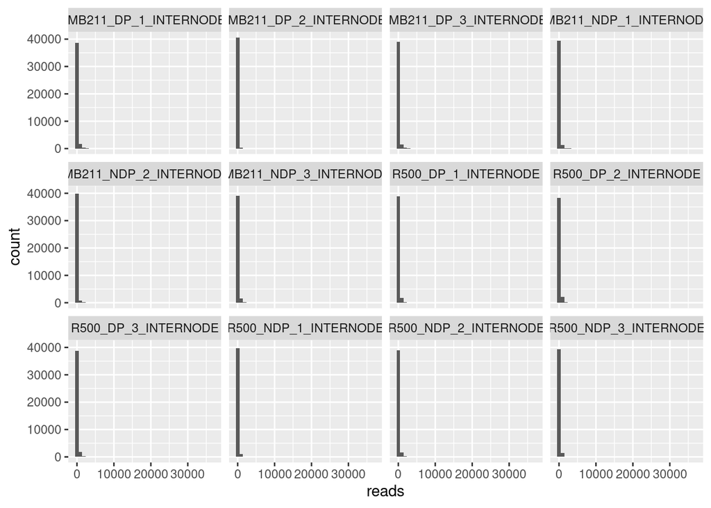

```r
basichist <- ggplot(data=counts.data.long,aes(x= reads)) +
    geom_histogram(bins = 40) +
    facet_wrap(facets = ~ sample)
normalhist <- ggplot(data=counts.data.long,aes(x= reads)) +
    geom_histogram(bins = 50) +
    facet_wrap(facets = ~ sample) +
    scale_x_log10()
basichist
```

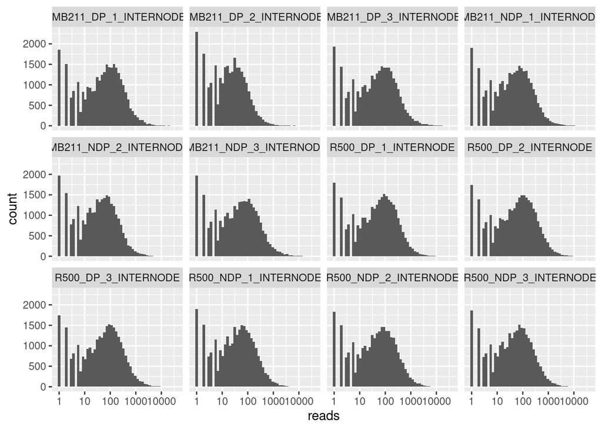

```r
normalhist
```

```r
#Trying to find the non-finite values
#sum(is.na(counts.data.long$reads))
#sum(is.na(counts.data.long$sample))
#sum(is.na(counts.data.long$gene_id))
```

**b.** Is the data normally distributed? Make a new set of histograms after applying an appropriate transformation if needed.

No, I had to add `+ scale_x_log10()` to scale the x axis to make it look normal.

**Hint 1**: *You probably need to `pivot_longer` the data into long format. See the Rice SNP lab and pivoting tutorial if you need a review*. **Hint 2**: *You can transform the axes in ggplot by adding* `scale_x_log10()` or `scale_x_sqrt()` *to the plot. One of these should be sufficient if you need to transform, but for other ideas see the [Cookbook for R page](http://www.cookbook-r.com/Graphs/Axes_%28ggplot2%29/#axis-transformations-log-sqrt-etc)*.

**Exercise 5:**

```r
counts.data <- counts.data[rowSums(counts.data[,-1] > 10) >= 3,]
```

**a.** We expect that read counts, especially from biological replicates, will be highly correlated. Check to see if this is the case using the `pairs()` function and the `cor()` function.

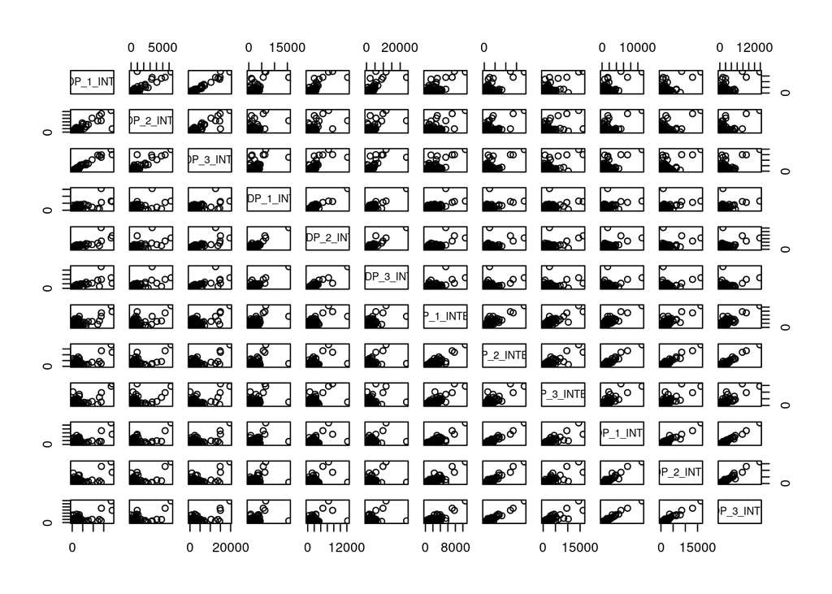

```r
pairtest.counts.data <- head(counts.data, 5000) %>%
    select(-gene_id)

pairs(pairtest.counts.data)
```

```r
coltest.counts.data <- select(counts.data, -gene_id)
cor.table <- cor(coltest.counts.data)
```

**b.** Once you have a correlation table, use the code provided to visualize it. Then, comment on the results from the pairs and correlation heatmap plots. Are the replicates more similar to each other than they are to other samples? Do you think there are any mistakes in the sample treatment labels?

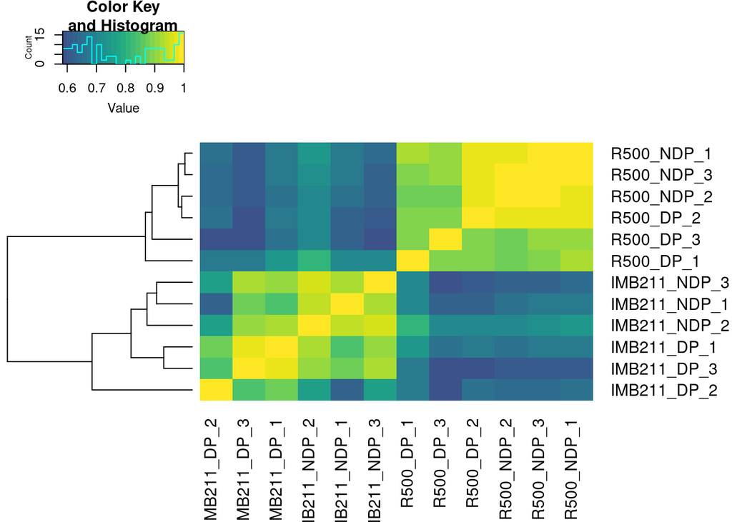

```r
rownames(cor.table) <- str_remove(rownames(cor.table), "_INTERNODE")
colnames(cor.table) <- str_remove(colnames(cor.table), "_INTERNODE")

cor.table %>% gplots::heatmap.2(dendrogram="row", trace = "none", col=viridis::viridis(25, begin=.25), margins=c(7,8))
```

There appears to be some correlation which can be seen in both pair and correlation plots. It appears that the replicates are more similar to each other than they are to the the other treatments. In the heatmap the two populations are very clearly different and the treatments are less clear but most visible in the bottom left quadrant. This can be seen in the dendogram with one exception. R500_NDP_2 and R500_DP_2 are equally related to each other. I don’t believe that there is any mislabelling.

**Important Hint:** *`pairs` is slow on the full dataset. Try it on the first 1,000 genes. Do you need to transform to make the pairs output more meaningful?*

**Important Hint2:** *it will be hard to see the pairs plot in the Rstudio inline display. Once you have the plot, click the expand to full window icon to display the plot in its own window. Alternatively, instead of using all columns of data, try it on a smaller number of columns*

**Hint 3:** *remember that you will need to remove the “gene_id” column before using the data in `pairs` or `cor`*

**Exercise 6:** Next use regular expressions, mutate, and the commands you learned in the stringr tutorial to create three new columns:

```r
sample.description <- tibble(sample=colnames(counts.data)[-1])
sample.description <- sample.description %>%
    mutate(sample.description, gt = str_replace(sample, "(.*)_(.*)_(.*)_(.*)", "\\1")) %>%
    mutate(sample.description, trt = str_replace(sample, "(.*)_(.*)_(.*)_(.*)", "\\2")) %>%
    mutate(sample.description, group = str_replace(sample, "(.*)_(.*)_(.*)_(.*)", "\\1_\\2"))
sample.description
```

| sample | gt | trt | group |
| --- | --- | --- | --- |
| IMB211_DP_1_INTERNODE | IMB211 | DP | IMB211_DP |
| IMB211_DP_2_INTERNODE | IMB211 | DP | IMB211_DP |
| IMB211_DP_3_INTERNODE | IMB211 | DP | IMB211_DP |
| IMB211_NDP_1_INTERNODE | IMB211 | NDP | IMB211_NDP |
| IMB211_NDP_2_INTERNODE | IMB211 | NDP | IMB211_NDP |
| IMB211_NDP_3_INTERNODE | IMB211 | NDP | IMB211_NDP |
| R500_DP_1_INTERNODE | R500 | DP | R500_DP |
| R500_DP_2_INTERNODE | R500 | DP | R500_DP |
| R500_DP_3_INTERNODE | R500 | DP | R500_DP |
| R500_NDP_1_INTERNODE | R500 | NDP | R500_NDP |

[output cut: 2 more lines]

1. column “gt” that has either IMB211 or R500, indicating the genotype
2. column “trt” that indicates the treatment with either “NDP” or “DP”
3. column “group” that has gt and trt pasted together with “_” as a separator. You can use `str_c()` and the “gt” and “trt” columns for this.

**Exercise 7**

```r
sample.description <- sample.description %>%
  mutate(gt=factor(gt),
         trt=factor(trt,levels = c("NDP","DP")))

sample.description
```

| sample | gt | trt | group |
| --- | --- | --- | --- |
| IMB211_DP_1_INTERNODE | IMB211 | DP | IMB211_DP |
| IMB211_DP_2_INTERNODE | IMB211 | DP | IMB211_DP |
| IMB211_DP_3_INTERNODE | IMB211 | DP | IMB211_DP |
| IMB211_NDP_1_INTERNODE | IMB211 | NDP | IMB211_NDP |
| IMB211_NDP_2_INTERNODE | IMB211 | NDP | IMB211_NDP |
| IMB211_NDP_3_INTERNODE | IMB211 | NDP | IMB211_NDP |
| R500_DP_1_INTERNODE | R500 | DP | R500_DP |
| R500_DP_2_INTERNODE | R500 | DP | R500_DP |
| R500_DP_3_INTERNODE | R500 | DP | R500_DP |
| R500_NDP_1_INTERNODE | R500 | NDP | R500_NDP |

[output cut: 2 more lines]

```r
library(edgeR)
```

```
## Note: the bcv method is now scheduled to be removed in a future release of edgeR.
```

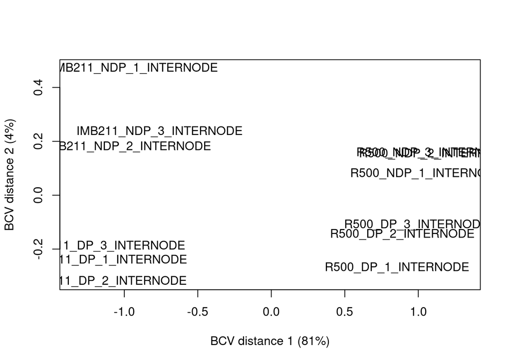

```r
counts.matrix <- counts.data %>% select(-gene_id) %>% as.matrix()
rownames(counts.matrix) <- counts.data$gene_id

dge.data <- DGEList(counts=counts.matrix,
                    group=sample.description$group)

dge.data <- calcNormFactors(dge.data, method = "TMM")
#dge.data$samples

plotMDS(dge.data, method = "bcv")
```

Discuss the MDS plot. Does it give you confidence in the experiment or cause concern?

It give me confidence because the largest reason of BCV is the population as we expected which is seen in BCV1 and the second biggest is the treatment as seen on BCV2. There is some concern with IMB211_NDP_1_INTERNODE not clustering with its replicates as well as the other combinations but overall the whole plots looks good.

**Exercise 8**

```r
counts.data.normal <- cpm(dge.data)
counts.data.normal.log <- cpm(dge.data,log = TRUE)
counts.data.log <- log2(counts.data[,-1] + 1)
```

To get a graphical idea for what the normalization does, make box plots of the count data for each sample before and after normalization. Discuss the effect of normalization.

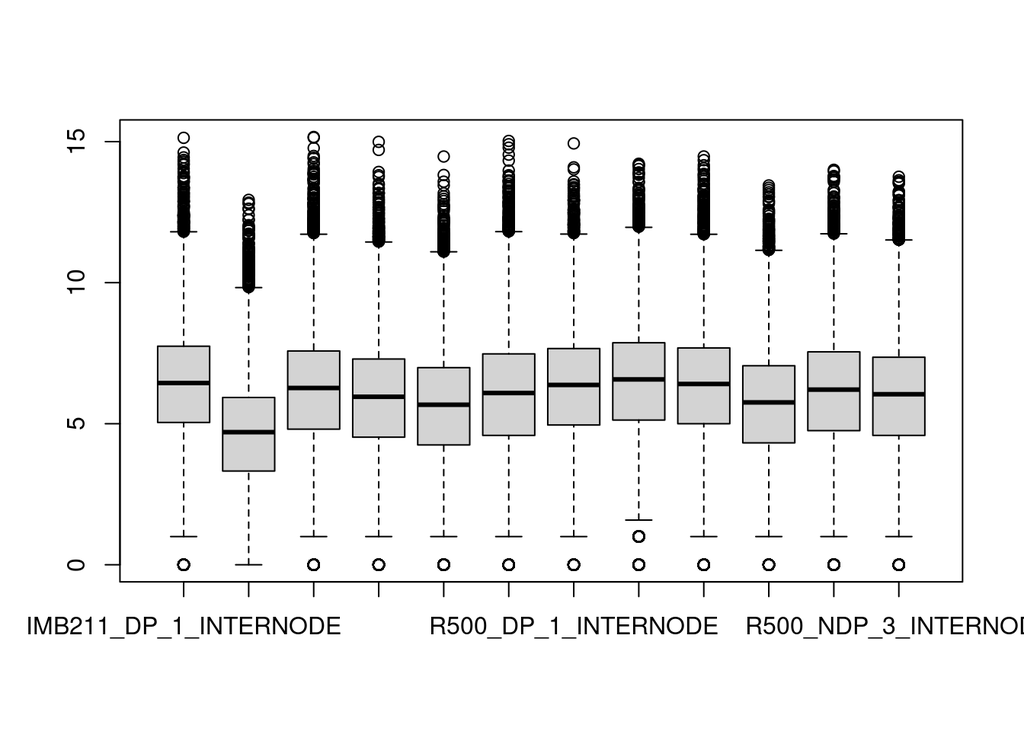

```r
boxplot(counts.data.log)
```

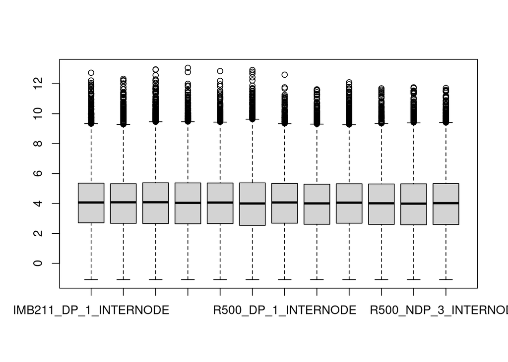

```r
boxplot(counts.data.normal.log)
```

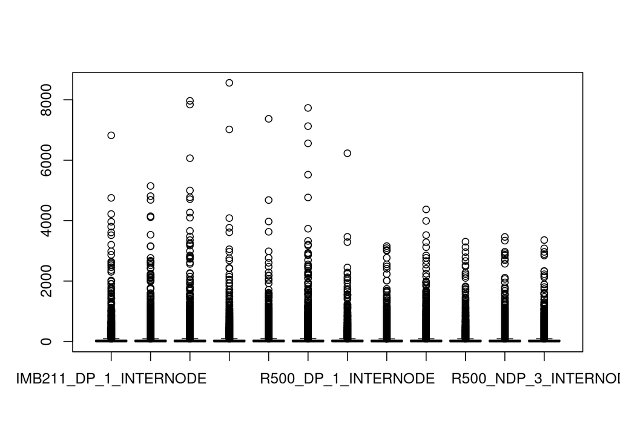

```r
boxplot(counts.data.normal)
```

Normalization makes it so that the samples are transformed so they their distributions have the roughly the same mean. This makes it easier to tell if the number of reads is due to differences in a sample versus if it was because of the differences between the samples. You need to use [,-1] when using `counts.data` because you have to exclude the gene_id column and you don’t have to do it with the `counts.data.normal` since the gene id’s are stored as the rownames.

**Hint 1**: _log2 transform the counts before plotting. Add a value of “1” before log2 transforming to avoid having to take the log2 of 0. Your transformation will look something like this:

```r
#counts.data.log <- log2(counts.data[,-1] + 1)
```

**Hint 2**: *If you don’t want to bother with `pivot_longer()` before going to ggplot, you can just use the `boxplot()` function and feed it the (transformed) matrix directly.*

**Hint 3**: Why do I use `[,-1]` above? Do you need to use this on `counts.data.normal`?

**Exercise 9**

```r
#dictate exp design
design <- model.matrix(~gt+trt,data = sample.description)
rownames(design) <- sample.description$sample
design
```

```
##                        (Intercept) gtR500 trtDP
## IMB211_DP_1_INTERNODE            1      0     1
## IMB211_DP_2_INTERNODE            1      0     1
## IMB211_DP_3_INTERNODE            1      0     1
## IMB211_NDP_1_INTERNODE           1      0     0
## IMB211_NDP_2_INTERNODE           1      0     0
## IMB211_NDP_3_INTERNODE           1      0     0
## R500_DP_1_INTERNODE              1      1     1
## R500_DP_2_INTERNODE              1      1     1
## R500_DP_3_INTERNODE              1      1     1
## R500_NDP_1_INTERNODE             1      1     0
## R500_NDP_2_INTERNODE             1      1     0
## R500_NDP_3_INTERNODE             1      1     0
## attr(,"assign")
## [1] 0 1 2
## attr(,"contrasts")
## attr(,"contrasts")$gt
## [1] "contr.treatment"
##
## attr(,"contrasts")$trt
## [1] "contr.treatment"
```

```r
#Common dispersion and trended graph
dge.data <- estimateGLMCommonDisp(dge.data,design,verbose = TRUE)
```

```
## Disp = 0.058 , BCV = 0.2408
```

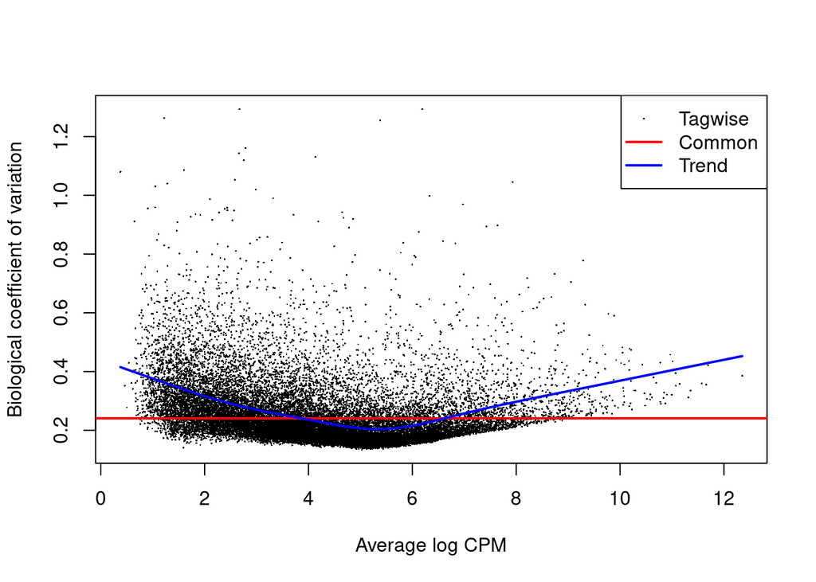

```r
dge.data <- estimateGLMTrendedDisp(dge.data,design)
dge.data <- estimateGLMTagwiseDisp(dge.data,design)
plotBCV(dge.data)
```

```r
#Finding diferentially expressed genes w/ TRT b/w full and reduced model.
fit <- glmFit(dge.data, design)
trt.lrt <- glmLRT(fit,coef = "trtDP")
topTags(trt.lrt)
```

```
## Coefficient:  trtDP
##               logFC   logCPM        LR       PValue          FDR
## Bra028803 -5.043456 3.514222 132.19854 1.353794e-30 3.253708e-26
## Bra019324  4.809736 2.209125  76.43637 2.274245e-18 2.732960e-14
## Bra034565  4.081287 2.159299  68.93414 1.018070e-16 8.156098e-13
## Bra025587  4.190919 3.298713  55.04401 1.178607e-13 7.081660e-10
## Bra029946  2.280844 5.364465  47.80173 4.715750e-12 1.898675e-08
## Bra026156  1.764672 6.467797  47.50653 5.482100e-12 1.898675e-08
## Bra030161  2.846792 5.105622  47.48949 5.529969e-12 1.898675e-08
## Bra037739  2.041482 4.539958  47.09441 6.764829e-12 2.032324e-08
## Bra016050  5.119232 1.755334  46.01184 1.175405e-11 3.138855e-08
## Bra029042  3.496552 1.240656  45.59897 1.451181e-11 3.487769e-08
```

```r
#Summarise Differentially expressed genes
summary(decideTestsDGE(trt.lrt,p.value=0.01))
```

```
##        trtDP
## Down     199
## NotSig 23415
## Up       420
```

```r
#table of differentially expressed genes
DEgene.trt <- topTags(trt.lrt,n = Inf,p.value = 0.01)$table
write.csv(DEgene.trt,"../output/DEgenes.trt.csv")
DEgene.trt.all <- topTags(trt.lrt,n = Inf, p.value = 1)$table
write.csv(DEgene.trt.all,"../output/DEgenes.trt.all.csv")

#Plotting fxn
plotDE <- function(genes, dge, sample.description) {
  tmp.data <- t(log2(cpm(dge[genes,])+1))
  tmp.data <- tmp.data %>%
    as.data.frame() %>%
    rownames_to_column("sample") %>%
    left_join(sample.description,by="sample")
  tmp.data <- tmp.data %>%
    pivot_longer(cols=starts_with("Bra"), values_to = "log2_cpm", names_to = "gene")
  pl <- ggplot(tmp.data,aes(x=gt,y=log2_cpm,fill=trt))
  pl <- pl + facet_wrap( ~ gene)
  pl <- pl + ylab("log2(cpm)") + xlab("genotype")
  pl <- pl + geom_boxplot()
  pl + theme(axis.text.x  = element_text(angle=45, vjust=1,hjust=1))
}

#rownames(DEgene.trt)[1:9]
```

**a**. Find all genes differentially expressed in response to the DP treatment (at a FDR < 0.01).

Saved in DEgene.trt

```r
DEgene.trt
```

|  | logFC | logCPM | LR | PValue | FDR |
| --- | --- | --- | --- | --- | --- |
| Bra028803 | -5.0434559 | 3.5142220 | 132.19854 | 1.353794e-30 | 3.253708e-26 |
| Bra019324 | 4.8097356 | 2.2091248 | 76.43637 | 2.274245e-18 | 2.732960e-14 |
| Bra034565 | 4.0812870 | 2.1592988 | 68.93414 | 1.018070e-16 | 8.156098e-13 |
| Bra025587 | 4.1909194 | 3.2987130 | 55.04401 | 1.178607e-13 | 7.081660e-10 |
| Bra029946 | 2.2808444 | 5.3644647 | 47.80173 | 4.715750e-12 | 1.898675e-08 |
| Bra026156 | 1.7646721 | 6.4677974 | 47.50653 | 5.482100e-12 | 1.898675e-08 |
| Bra030161 | 2.8467916 | 5.1056216 | 47.48949 | 5.529969e-12 | 1.898675e-08 |
| Bra037739 | 2.0414823 | 4.5399575 | 47.09441 | 6.764829e-12 | 2.032324e-08 |
| Bra016050 | 5.1192317 | 1.7553341 | 46.01184 | 1.175405e-11 | 3.138855e-08 |
| Bra029042 | 3.4965524 | 1.2406562 | 45.59897 | 1.451181e-11 | 3.487769e-08 |

[output cut: 609 more lines]

**b**. How many genes are differentially expressed?

619

```r
count(DEgene.trt)
```

| n |
| --- |
| 619 |

**c**. Make a plot of the top 9

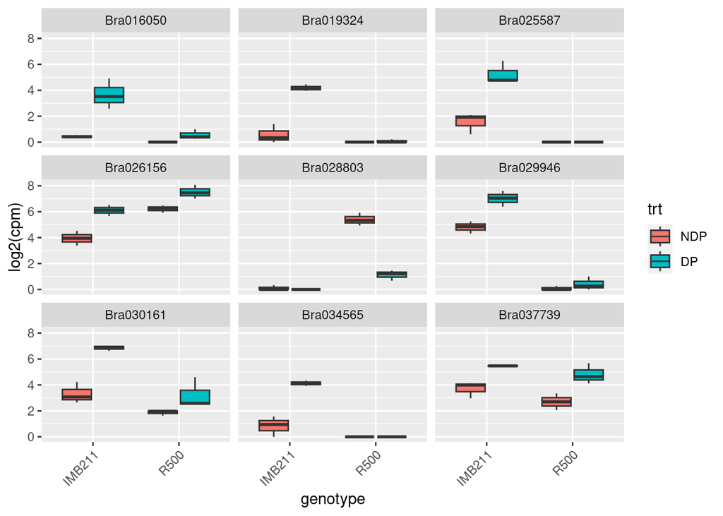

```r
plotDE(rownames(DEgene.trt)[1:9],dge.data,sample.description)
```

**Exercise 10**: Gene by treatment interaction

```r
#dictate exp design
design.interaction <- model.matrix(~gt*trt,data = sample.description)
rownames(design.interaction) <- sample.description$sample
design.interaction
```

```
##                        (Intercept) gtR500 trtDP gtR500:trtDP
## IMB211_DP_1_INTERNODE            1      0     1            0
## IMB211_DP_2_INTERNODE            1      0     1            0
## IMB211_DP_3_INTERNODE            1      0     1            0
## IMB211_NDP_1_INTERNODE           1      0     0            0
## IMB211_NDP_2_INTERNODE           1      0     0            0
## IMB211_NDP_3_INTERNODE           1      0     0            0
## R500_DP_1_INTERNODE              1      1     1            1
## R500_DP_2_INTERNODE              1      1     1            1
## R500_DP_3_INTERNODE              1      1     1            1
## R500_NDP_1_INTERNODE             1      1     0            0
## R500_NDP_2_INTERNODE             1      1     0            0
## R500_NDP_3_INTERNODE             1      1     0            0
## attr(,"assign")
## [1] 0 1 2 3
## attr(,"contrasts")
## attr(,"contrasts")$gt
## [1] "contr.treatment"
##
## attr(,"contrasts")$trt
## [1] "contr.treatment"
```

**a**. Repeat the dispersion estimates and model fit but with the new model. Show code.

```r
#Common dispersion and trended graph
dge.data.interaction <- estimateGLMCommonDisp(dge.data,design.interaction,verbose = TRUE)
```

```
## Disp = 0.0516 , BCV = 0.2272
```

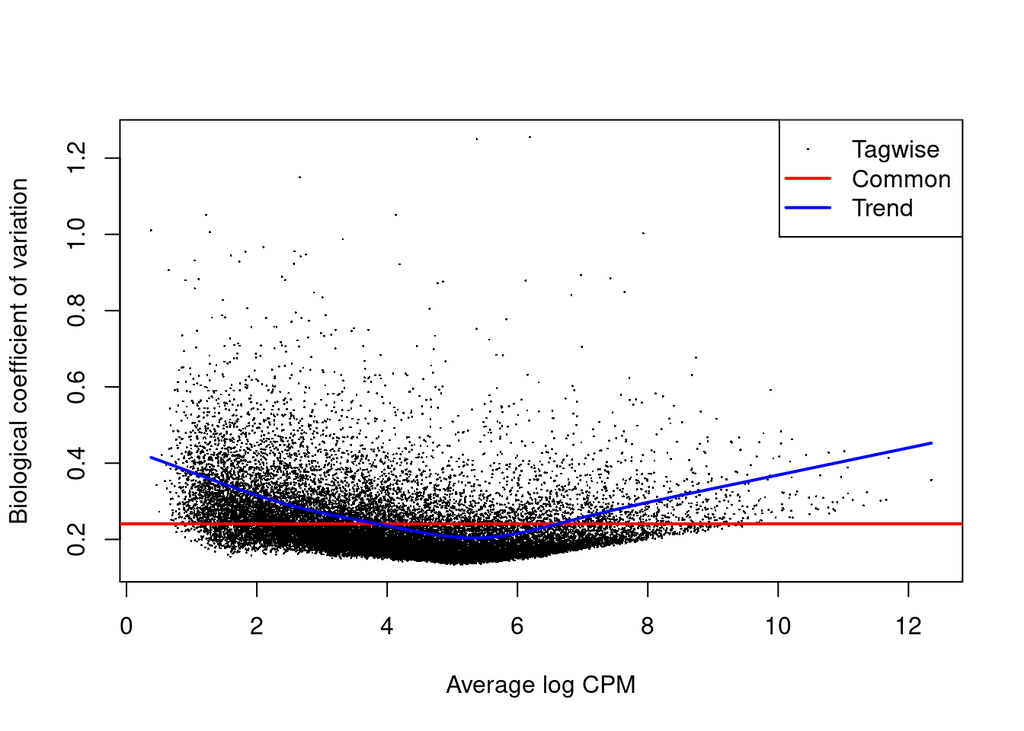

```r
dge.data.interaction <- estimateGLMTrendedDisp(dge.data,design.interaction)
dge.data.interaction <- estimateGLMTagwiseDisp(dge.data,design.interaction)
plotBCV(dge.data.interaction)
```

**b**. How many genes show a significantly different response to treatment in IMB211 as compared to R500? Save these genes to a file.

Significantly different genes written in “../output/DEgenes.inter.csv”

```r
fit <- glmFit(dge.data.interaction, design.interaction)
inter.lrt <- glmLRT(fit,coef = "gtR500:trtDP")
#topTags(inter.lrt)

summary(decideTestsDGE(inter.lrt,p.value=0.01))
```

```
##        gtR500:trtDP
## Down            115
## NotSig        23780
## Up              139
```

```r
DEgene.inter <- topTags(inter.lrt,n = Inf,p.value = 0.01)$table
write.csv(DEgene.inter,"../output/DEgenes.inter.csv")
DEgene.inter.all <- topTags(inter.lrt,n = Inf, p.value = 1)$table
write.csv(DEgene.inter.all,"../output/DEgenes.inter.all.csv")
```

**c**. Make a plot of the top 9 genes that have a significantly different response to treatment in IMB211 as compared to R500.

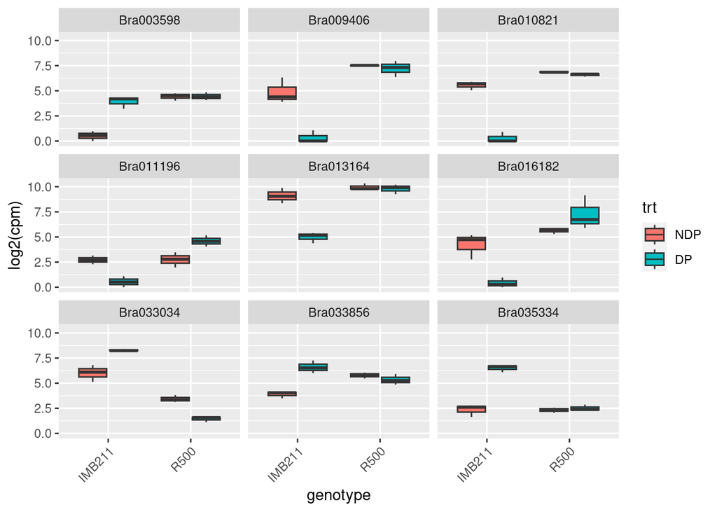

```r
plotDE(rownames(DEgene.inter)[1:9],dge.data.interaction,sample.description)
```